# A Sales Dataset Analysis of a Retail outlet in the U.S.

## By Barry Quist

### Questions for Analysing dataset

1. What is the most and least expensive product?
2. What are the best and worst sellers of the outlet for the year 2019?
3. What is the sales trend of the outlet for 2019?
4. Which cities had the most and least purchases?
5. What is the distribution of products sold across these cities?
6. What is the distribution of products sold across month?
7. What time of the day were orders made most?
8. What is the distribution of orders during the time of day across Month?
9. What is the distribution of orders during the time of day across Cities?

## Question 1: What is the most and least expensive product?

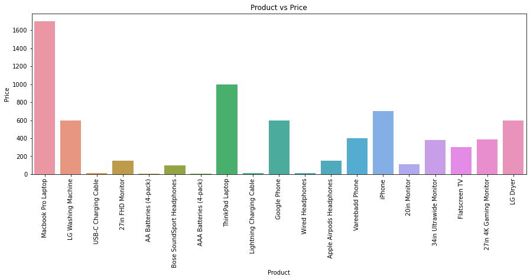

### Observation

- The Macbook Pro Laptop was the most expensive product in the outlet.
- The AAA Batteries (4-pack) was the least expensive item in the outlet.

## Question 2: What are the best and worst sellers of the outlet for the year 2019?

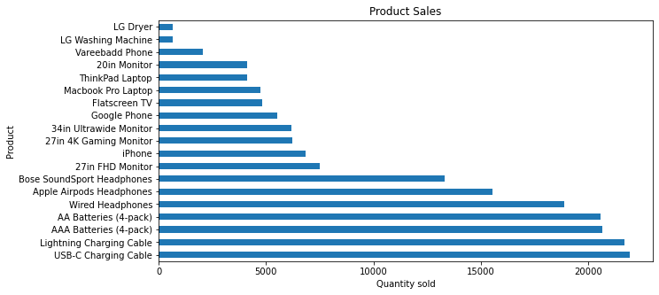

### Observation

- The USB-C charging cable was the most purchased product.
- On the other hand, the LG Dryer was the least sold product.

## Question 3: What is the sales trend of the outlet for 2019?

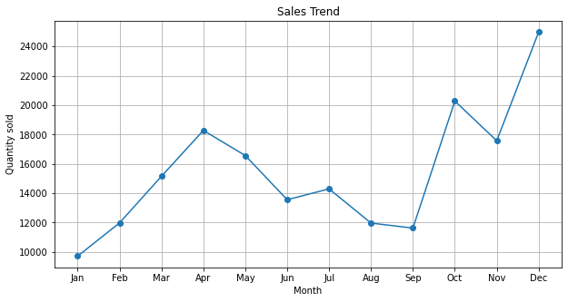

### Observation

- December had the most products sold.
- January had the least number of products sold

## Question 4: Which cities had the most and least products purchased?

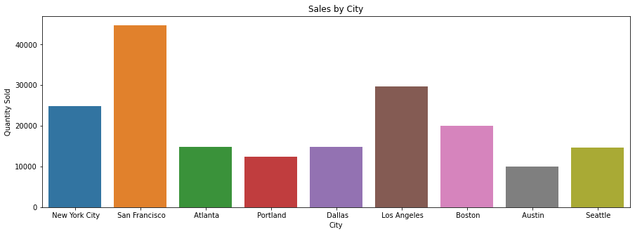

### Observation

- It is observed that San Francisco made the most purchases.
- Contrary to this Austin made the least purchase of products from the outlet.

## Question 5: What is the distribution of products sold across cities?

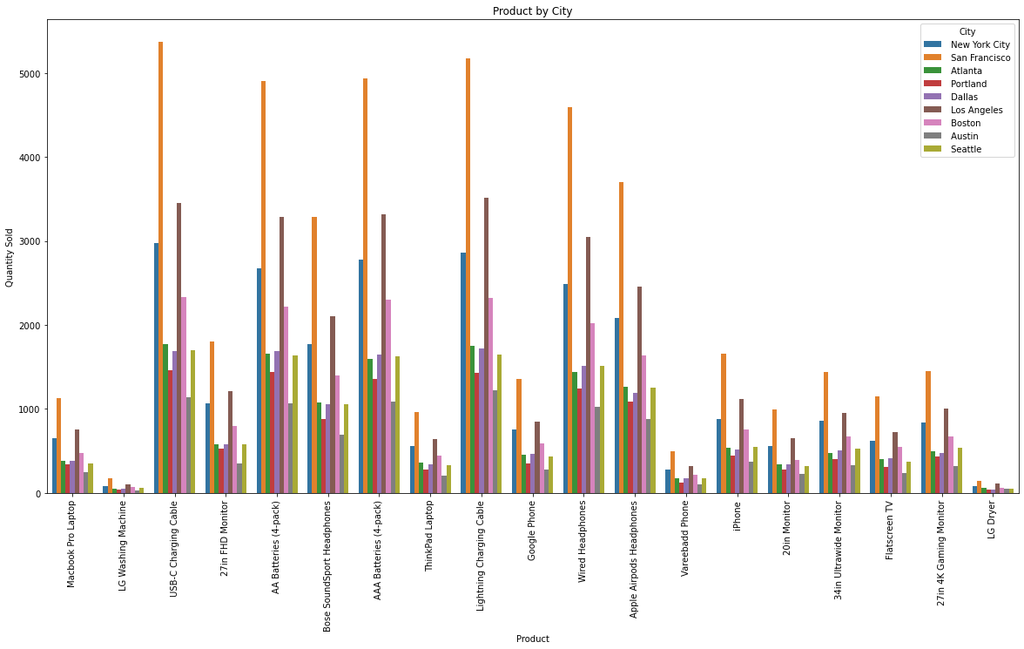

### Observation

- It is observed that San Francisco had the largest margins of all product purchases across all the cities.

## Question 6: What is the distribution of products sold across month?

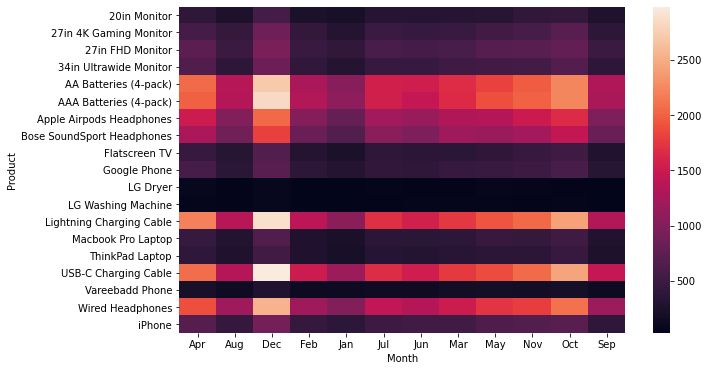

### Observation

December saw a lot of products being purchased.

## Question 7: What time of the day were orders made most?

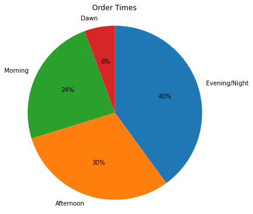

### Observation

- It is observed that 40% of orders were made in the Evenings/Nights, 30% in the afternoons, 24% in the mornings and 6% at Dawn.
- There was also a relative increase in purchase orders as the day went by i.e from Dawn to Evening/Night

## Question 8: What is the distribution of orders during the time of day across Month?

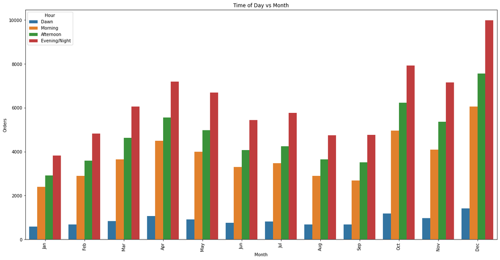

### Observation

- It is observed from the plot above that a lot more orders were placed in the Evenings/Night all throughout the year

## Question 8: What is the distribution of orders during the time of day across Cities?

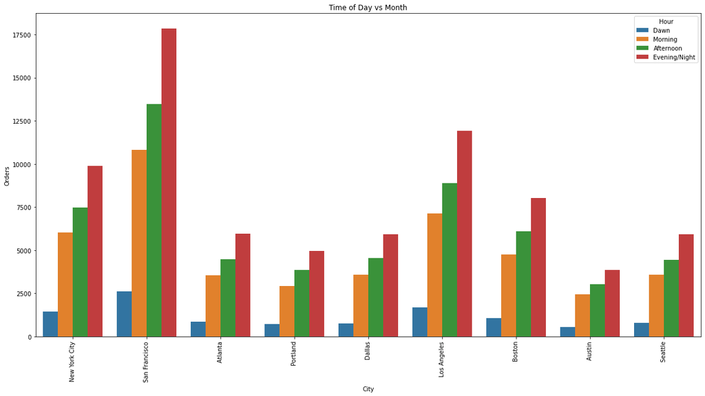

### Observation

- It is observed from the plot above that all cities had a lot more orders/purchases placed in the Evenings/Nights.

## Conclusion

In conclusion, San Francisco was the city with the highest orders/purchases compared to the other cities. It was observed that there were a lot of purchases mostly for AAA Batteries (4-pack), AA Batteries (4-pack), USB-C Charging Cable and the Lightning Charging Cable.

All these were mostly purchased during December in the afternoons and evenings/nights. Could this be because of the Christmas festivities during that period? Although San Francisco is not as densely populated as New York and Los Angeles, it still had the most purchases. So what could be the reason for this? Further research yeilded that all cities equally had activities for December. Therefore we conclude generally that the reason for most purchases by all cities in December was because of Christmas festivities. It is assumed that people purchased products to be wrapped as gifts for loved ones.

Again a question is asked "But why are the most purchased products by San Francisco the least expensive ones?". Further research revealed that Los Angeles, New York and San Francisco were in the [top 10 most expensive cities in the US](https://www.investopedia.com/articles/personal-finance/080916/top-10-most-expensive-cities-us.asp#:~:text=In%20the%20U.S.%2C%20New%20York,the%20world%27s%20most%20expensive%20cities). This can be a reason to why the least expensive products were purchased, mostly because one's income might be used to pay for bills and other living expenditures and due to the high cost of living, one might not have enough to spend on pricey items.

However from the analysis, we can note that the outlet's peak period were in the Evenings/Nights since there were alot more orders/purchases during that time of the day.